# datawarehouseday1

print("Data warehouse is my House")

```python
print("Power Bi Data warehouse")
```

```
Power Bi Data warehouse
```

```python
print("Data Sources>>ETL>>{Data warehouse}>>{Reporting &Analytics &Data-Mining}")
```

```
Data Sources>>ETL>>{Data warehouse}>>{Reporting &Analytics &Data-Mining}
```

```python
print("Business Intelligence & Data Warehousing")
```

```
Business Intelligence & Data Warehousing
```

[figure not shown]

```python
print("ITI DWH Day 01")
```

```
ITI DWH Day 01
```

```python
print("Gartner>>Gartner | Delivering Actionable")
```

```
Gartner>>Gartner | Delivering Actionable
```

```python
print("Microsoft Power BI<<>>Tableau")
```

```
Microsoft Power BI<<>>Tableau
```

```python
print("------------------------------------------")
```

1>>Business intelligence (BI) and Analytics. 2>>Mobile app development. 3>>Cloud computing.

4>>Data science and Data analytics

> > Data Warehousing Improve Decision Making<<

```python
print("Data warehouse & Decision making")
```

```
Data warehouse & Decision making
```

Data>>Information>>Knowledge>>Decision

> > Introduction to DWH<<

Data As a Product To Use in data management and analytics As facebook,google and talabat >>Data support product.

> > Analysis The Data to know Customer behaviour

> > Customer Buy Behaviors سلوكيات الشراء لدى العملاء

> > Collect Data from Variety of Sourcesجمع البيانات من مجموعة متنوعة من المصادر\n

1>>Performanceأداء. 2>>Integrationاندماج. 3>>Applying Analytical Functions. 4>>Aggregate Functions and Data Mining.

> > DWH all Organization Data in One Place

```python
print("--------------Applying Analytical Functions----------------")
```

```
--------------Applying Analytical Functions----------------
```

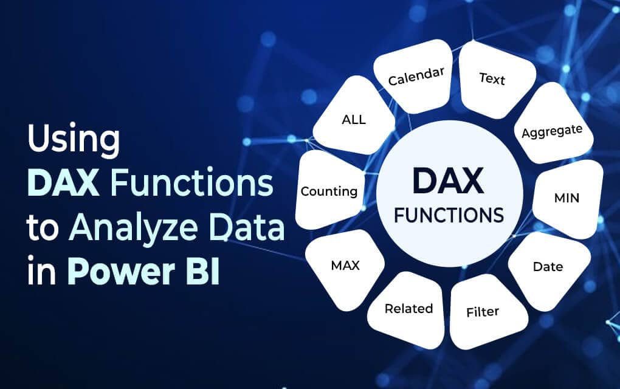

Data-Analysis-Expressions>>22 Powerful DAX Formulas and Functions for Beginners: A Deep Dive into Data Analysis Expressions in Power BI.

> > Definition of Data Warehouse (DWH)

> > A DWH is a technique for collecting and managing data from varied sources to provide meaningful business insights.

> > varied-sources:-Excel files,flat files,web data,organization data system and Databases.

> > To Provide MeaningFul Business Insightsلتوفير رؤى تجارية ذات معنى.

> > Meaningful-Business-Insights for Decision Making.

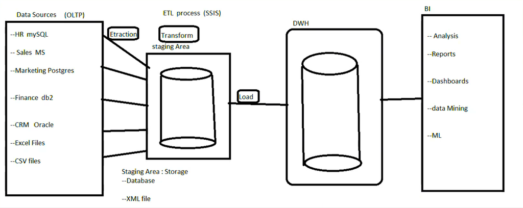

```python
"""
>>Online-Transaction-Processing<<
1>>Extract data.
2>>Transform data>>Data cleaning & Handle null values & Data Types & Merge.
3>>Load Data.
4>>Extract, Transform, and Load (ETL)>>ETL Process SSIS.
5>>ETL In Data Warehouse>>Single source of Truth>>Single Point Of Truth.
"""
```

```
'\n>>Online-Transaction-Processing<<\n1>>Extract data.\n2>>Transform data>>Data cleaning & Handle null values & Data Types & Merge.\n3>>Load Data.\n4>>Extract, Transform, and Load (ETL)>>ETL Process SSIS.\n5>>ETL In Data Warehouse>>Single source of Truth>>Single Point Of Truth.\n'
```

```python
print("-------Data-Warehouse--------")
```

```
-------Data-Warehouse--------
```

> > The DWH is the core جوهر of the BI system build for Data Analysis and Reporting.

> > The DWH is not a product but An Environment.

> > Timely Manner To Make a Difference.

> > Other Names for the Data Warehouse system:-

1>>Decision Support System(DSS).

2>>Business Intelligence Solution.

3>>Excutive Information System.

4>>Management Information System.

5>>Analytic Application.

6>>Data Warehouse.

```python
print("------Database vs Data Warehouse-----------")
```

```
------Database vs Data Warehouse-----------
```

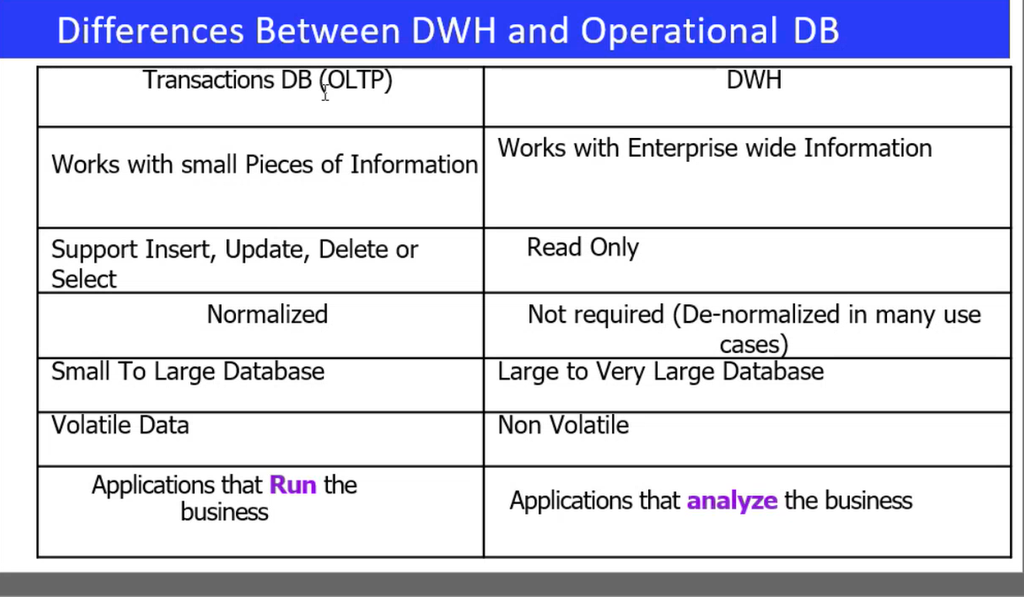

Volatileمتطاير

Data warehouse Work with Enterprise wide informationمستودع البيانات العمل مع المعلومات على مستوى المؤسسة

Database>>DB Insert New Customer,New Order.

DWH>>OLAP>>تعمل علي كل بيانات المؤسسة

DWH>>Read Only.

Volatile Data>>Insert Update Delete.

Non Volatile>>Read and Select Only.

DWH>>Applications that Analyze The Business.

DWH>>Output>>Meaningful Business Insights.

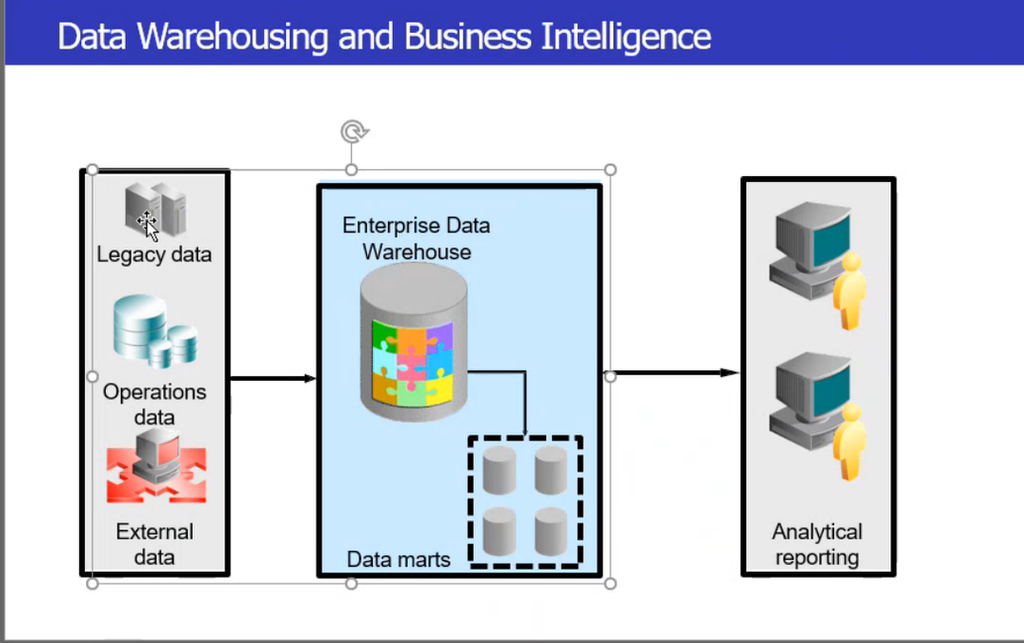

Definition OF BI

Data Warehouse is core of Business Intelligence

```python
"BI Helps transform Data,To information(and KonwLedge), to Decisions and Finally to Action."
```

```
'BI Helps transform Data,To information(and KonwLedge), to Decisions and Finally to Action.'
```

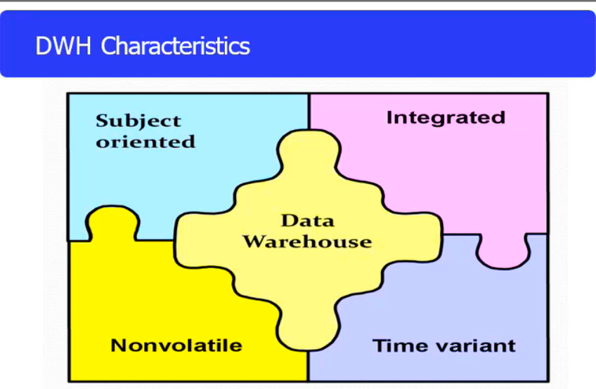

```python
"Anything in Data Warehouse Attachment to The Date As Date(Dim)"
```

```
'Anything in Data Warehouse Attachment to The Date As Date(Dim)'
```

types of DWH Types Of Data Warehouse

> > Types Of Data Warehouse

1>>Enterprise Data Warehouse (EDWH)>>Decision support system..

2>>Operational Data Store (ODS)>>up-to-date(real-time).

3>>Data Mart>>A departmental data warehouse>>Line of Business>>Such As Sales or Finance.

> > Data Mart>>AS>>Data Warehouse For Sales

> > Data Mart Data Warehouse For Finance.

> > Data Mart Data Warehouse For Marketing

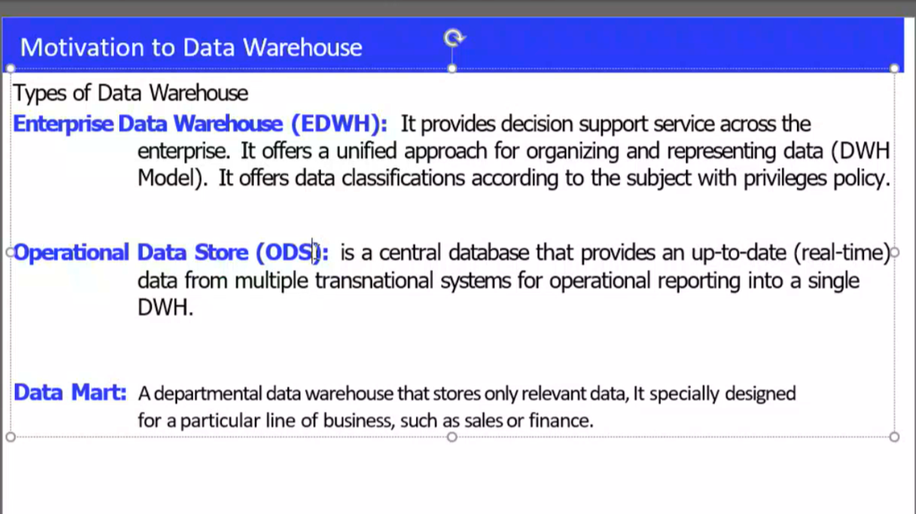

> > DataMart A Departmental Data Warehouse For Line As>>Sales,HR,Marketing,CRM and Finance.

> > DataMart هو مستودع بيانات إداري لخطوط الإنتاج>>المبيعات والموارد البشرية والتسويق وإدارة علاقات العملاء والمالية.

> > Customer relationship managementإدارة علاقات العملاء

```python
print("----------------------------------------------------")
```

> > Data Marts offer Improved Performance.

```python
print("----------------------------------------------------")
```

```python
print("Data From Difference Source>>Data Cleaning As Same Structure")
```

```
Data From Difference Source>>Data Cleaning As Same Structure
```

```python
print("Data in Data Warehouse Must have Same Structure")
```

```
Data in Data Warehouse Must have Same Structure
```

```python
print("As FullName and Another FName&LName")
```

```
As FullName and Another FName&LName
```

```python
print("0&1 As Male&Female Must 0&1 Become Male&Female")
```

```
0&1 As Male&Female Must 0&1 Become Male&Female
```

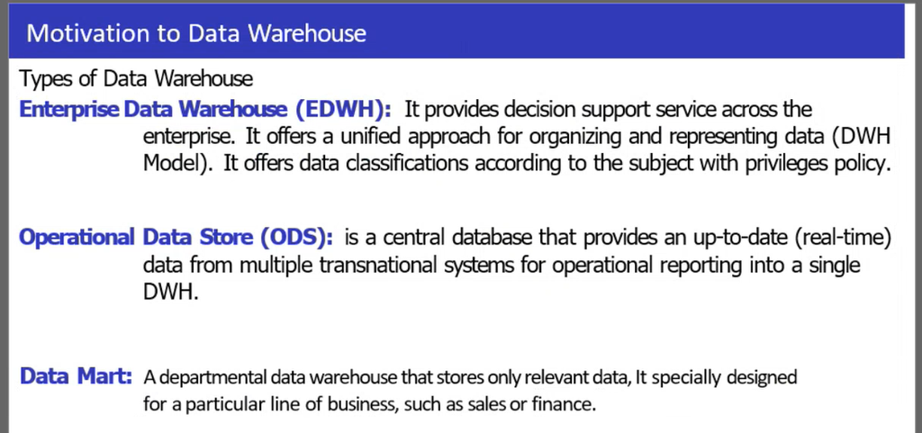

> > EDWH & ODS & Data Mart

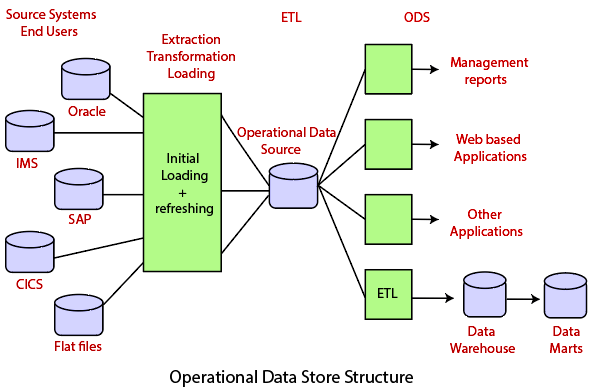

> > Operational data stores contain only the most current operational dataتحتوي مخازن البيانات التشغيلية فقط على أحدث البيانات التشغيلية..

> > up-to-date-real-timeأحدث البيانات التشغيلية.

اي شي يحصل جديد put into ODS

```python
print("$$"*20)
```

```
$$$$$$$$$$$$$$$$$$$$$$$$$$$$$$$$$$$$$$$$
```

```python
print(">>Use Surrogate Key As Primary Key,Better Than Use Natural Key As Phone Number<<")
```

```
>>Use Surrogate Key As Primary Key,Better Than Use Natural Key As Phone Number<<
```

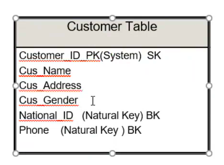

> > What's the difference between a Data Lake and a Data Warehouse?

> > Data lakes store all types of raw data, which data scientists may then use for a variety of projects.

> > Data warehouses store cleaned and processed data, which can then be used to source analytic or operational reporting, as well as specific BI use cases.

```python
print("***"*30)
```

Data warehouse for business intelligence

Data Lake for Data Scientist and Data Engineers

```python
print("***"*30)
```

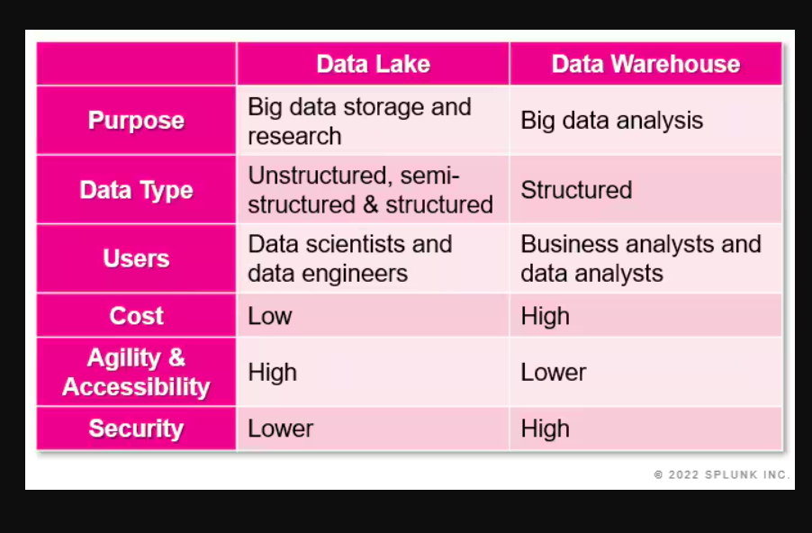

> > Difference Between Kim-ball and In-mon

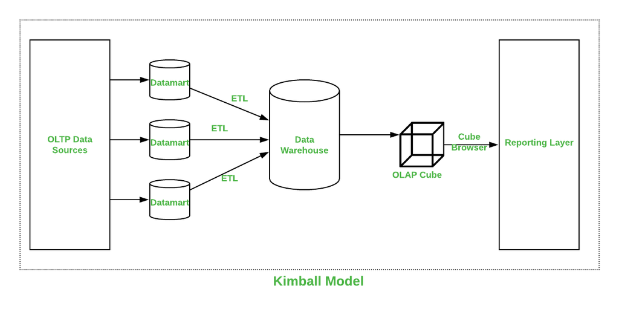

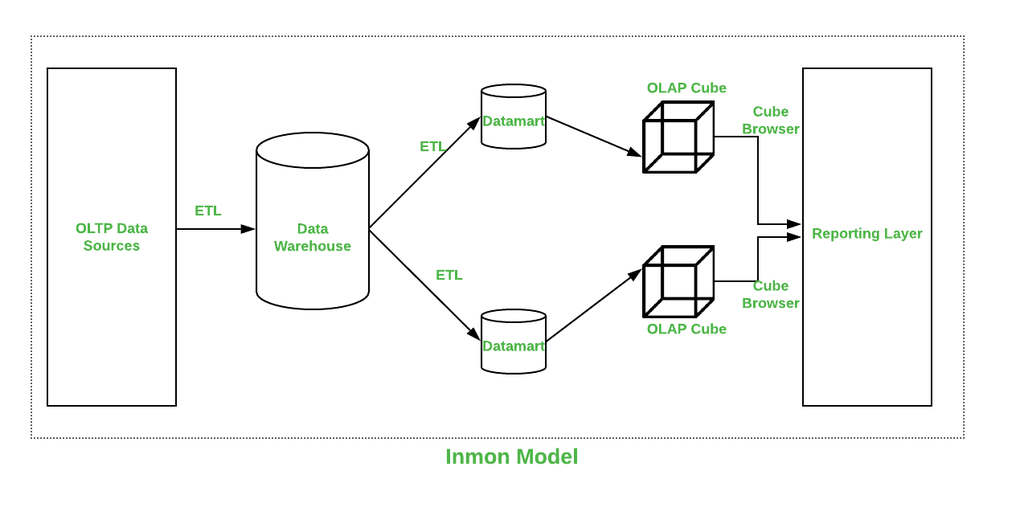

The Star Schema in Data Warehouse modeling

> > Features Of Star Schema

```python
print("$$$"*30)
```

```
$$$$$$$$$$$$$$$$$$$$$$$$$$$$$$$$$$$$$$$$$$$$$$$$$$$$$$$$$$$$$$$$$$$$$$$$$$$$$$$$$$$$$$$$$$
```

> > FACT Table

> > Fact and Dim Tables

> > Fact tables contain numerical data, while dimension tables provide context and background information Effective Data Analysis and Decision-Making.

> > Fact Table Have Measures and Foreign Key

> > The Fact Table's Primary Key is usually a composite of the Foreign Key Columns, Although it can also be a Surrogate Key.

> > The Fact Table Contains Foreign Keys From The Dimension Tables.

> > Measures in Fact Table As Sum Avg Count Written in Data Analysis Expressions (DAX) Formulas.

> > Dimension Tables contain PK & Descriptions of the objects in a Fact Table.

The Star Schema Features:-

> > 1>>Central Fact Table:Contains The Numerical Data Being Analyzed & Contains Foreign Keys to link to Dimension Tables.

> > 2>>Dimension Tables.

> > 3>>DB Denormalized Structure.

> > 4>>Simple&Fast Queries>>By Joining The Fact Table With Dimension Tables.

> > 5>>Aggregated Data>>(Sum, Average, and So On) in Power BI.

> > 6>>Fast Performance & Fast Query Performance.

> > 7>>Easy To Understand.

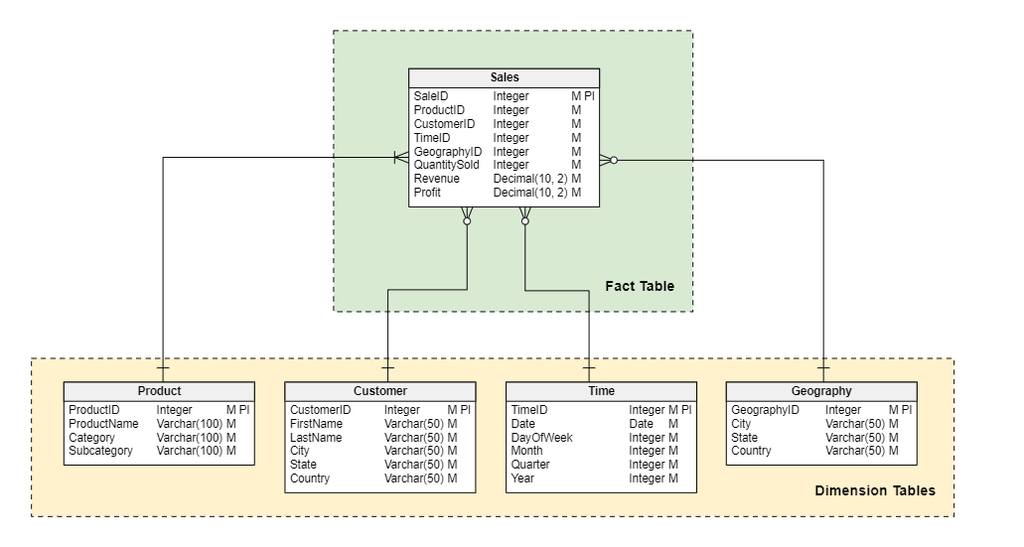

> > This is the New America We are the New America.

> > End Of Day 1 Data Warehousing ITI

> > A data warehouse is an enterprise system used for the analysis and reporting of structured and semi-structured data from multiple sources.

> > مستودع البيانات هو نظام مؤسسي يستخدم لتحليل وإعداد التقارير عن البيانات المنظمة وشبه المنظمة من مصادر متعددة.